# Reshaping Data

In this notebooks, we’ll work with functions from the tidyr library on data from the State of Tennessee Department of Health: https://www.tn.gov/health/health-program-areas/statistics/health-data/death-statistics.html

This data comes in an Excel file, so you’ll need to install the readxl library if you haven’t already done so.

```r
library(tidyverse)
library(readxl)
```

We’ll start by reading in the data for the DAVIDSON region. Remember that you can use ?read_excel if you want more information on how this function works. Start by using read_excel to grab the data from the “DAVIDSON” sheet from cell A7 through cell M19.

```r
cause_of_death <- read_excel('../data/LCD_byRegionSex_2019.xlsx', range='DAVIDSON!A7:M19')
```

The column names are not very good, so let’s rename them. If we can create a vector of column names, we can use the rename_with function to rename all columns at once.

```r
column_names <- c("cause",
                  "total_rank", "total_number", "total_rate", "total_age_adjusted",
                  "male_rank", "male_number", "male_rate", "male_age_adjusted",
                  "female_rank", "female_number", "female_rate", "female_age_adjusted")
```

Use the rename_with function with this vector of column names.

```r
cause_of_death <- cause_of_death |>
  rename_with(~ column_names)
```

If we wanted to create a plot to compare cause of death by sex, it would be quite difficult to do in the current format. Let’s reshape our data so that it is easier to plot.

See the tidyr cheat sheet here: https://raw.githubusercontent.com/rstudio/cheatsheets/main/tidyr.pdf

Use the pivot_longer funtion and pivot all but the cause column. The result should have 3 columns, cause, name, and value.

```r
cause_of_death <- cause_of_death |>
  pivot_longer(-cause)
```

Now, it would probably be best if we had separate columns for “sex” and “measure”. Let’s do that now. Use the separate_wider_delim function to separate the name column into two columns, “sex” and “measure”

```r
cause_of_death <- cause_of_death |>
  separate_wider_delim(cols = name, delim = '_', names = c('sex', 'measure'), too_many = "merge")
```

Now, we can create a bar chart to show the rate of death by cause with a side-by-side bar chart so that we can compare rates by sex.

To adjust the order that the bars are displayed, we can make use of the forcats library. See the cheat sheet here: https://raw.githubusercontent.com/rstudio/cheatsheets/main/factors.pdf. Make sure that the bars are sorted alphabetically by cause.

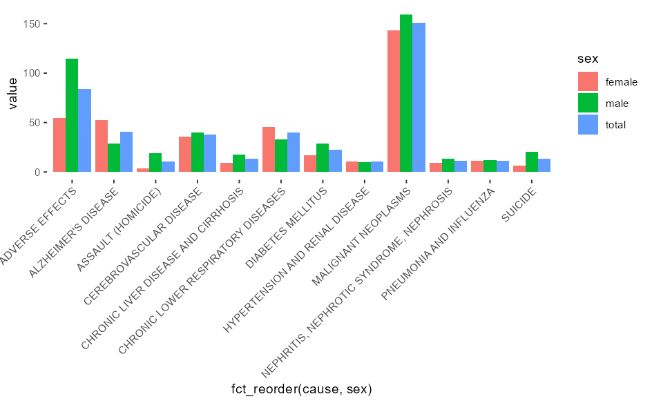

```r
library(forcats)

cause_of_death |>
  filter(measure == 'rate') |>
  group_by(cause) |>
  ggplot(aes(x= fct_reorder(cause, sex), y=value, fill=sex)) +
  geom_col(position='dodge', stat='identity') +
  theme(panel.background = element_blank(),
          axis.text.x = element_text(angle = 45, hjust = 1))
```

But, what if we don’t want to have to filter to what we want to plot each time and just want to specify a column? We can again reshape our data so that each measure is a column. Use the pivot_wider function to reshape your data so that it has one row per cause and sex and columns for rank, number, rate, and age-adjusted rate.

```r
cause_of_death <- cause_of_death |>
  pivot_wider(names_from = measure, values_from = value)
```

This code works to get the first region (DAVIDSON), but what if we want to pull in all counties? The easiest way might be to make a function.

Create a function which takes as input a sheet name and which reads in the data for that sheet and returns the reshaped tibble with the data for that sheet. Make sure to add a column which contains the sheet name. See the user-defined functions section of https://www.datacamp.com/tutorial/functions-in-r-a-tutorial for more information.

```r
library(glue)
```

```r
cod_func <- function(sheet){
  column_names <- c("cause",
                  "total_rank", "total_number", "total_rate", "total_age_adjusted",
                  "male_rank", "male_number", "male_rate", "male_age_adjusted",
                  "female_rank", "female_number", "female_rate", "female_age_adjusted")
  df <- read_excel('../data/LCD_byRegionSex_2019.xlsx',
                   range = glue('{sheet}!A7:M19')) |>
    rename_with(~ column_names) |>
    mutate_at(vars(-cause), as.double) |>
    pivot_longer(-cause) |>
    separate_wider_delim(cols = name,
                         delim = '_',
                         names = c('sex',
                                   'measure'),
                         too_many = "merge") |>
    pivot_wider(names_from = measure, values_from = value) |>
    mutate(county = glue('{sheet}'))
  return(df)
}
```

We can get a list of sheet names using the excel_sheets function.

```r
sheets <- readxl::excel_sheets('../data/LCD_byRegionSex_2019.xlsx')
```

Finally, use the map function (https://purrr.tidyverse.org/reference/map.html) to apply the function you created above to all of the sheets in the Excel file and combine them together into a single tibble.

```r
all_counties_cod <- map(sheets, cod_func) |>
  bind_rows()
```

[output not shown]